# Final Examination

Zillow Project

RASHMI PIYUSH SARODE

Wednesday, August 12, 2015

## Background

The purpose of this project is to forecast the final selling price of a chosen house using data obtained from Zillow.com. After registering at Zillow and obtaining a Zillow ID (ZWSID), we are able to stream the neccessary comparables data from the Zillow Web Services API into an R session. This data is then used to build a best regression prediction model. Fitted values and 95% predictional intervals are then compared to the price estimates and ranges, also provided by Zillow.com.

## Registering and obtaining a Zillow ID

To create an API account, one must register with Zilllow and obtain a *Zillow Web Services ID* (ZWSID) at the URL https://www.zillow.com/webservice/Registration.htm . The ZWSID is sent via email, and therefore it is important to check spam folders is one does not receive their ZWSID. The ZWSID is copied and saved into an R vector as character.

### The Property Choice, and Indentification

We went to htpps://www.Zillow.com and looked for a house that is for sale. *It could not be already sold or “off the market.”* Our chosen property must also have a Zillow estimate with low and high values, otherwise we chose a different property.

We obtain the Zillow Home ID, and the full address and zip code. We put these values into R vectors with appropriate names and run the R code to obtain a data frame of comparable, sold homes. The first row of the data frame is our choosen property.

```
## [1] "19 Rossmore Ter,\nLivingston, NJ 07039"
```

```
## [1] "38669488"
```

```
## [1] 679000
```

```
##  [1] "amount"            "low"               "high"
##  [4] "valueChange30Day"  "street"            "zip"
##  [7] "latitude"          "longitude"         "taxAssessmentYear"
## [10] "taxAssessment"     "yearBuilt"         "lotSizeSqFt"
## [13] "finishedSqFt"      "bathrooms"         "bedrooms"
## [16] "lastSoldPrice"     "lastSold"          "score"
```

We see there are several variables (columns) in the data frame that are not useful for a linear regression model. Therefore we create a data frame from a subset of these variables.

|  | amount | taxAssessment | yearBuilt | lotSizeSqFt | finishedSqFt | bathrooms | bedrooms | lastSoldPrice | lastSold | score |
| --- | --- | --- | --- | --- | --- | --- | --- | --- | --- | --- |
| 38669488 | 605655 | 527628 | 1963 | 13939 | 2088 | 3.0 | 4 | 619000 | 2012-08-03 | NA |
| 38665147 | 347990 | 327171 | 1929 | 4791 | 1303 | 1.5 | 3 | 337000 | 2014-09-10 | 14 |
| 38665583 | 465219 | 456377 | 1954 | 10018 | 1545 | 1.5 | 3 | 460800 | 2014-09-08 | 9 |
| 38665624 | 464129 | 365822 | 1930 | 5662 | 1820 | 3.0 | 3 | 570000 | 2015-05-05 | 5 |
| 38665665 | 479546 | 470710 | 1936 | 8002 | 1693 | NA | NA | 500000 | 2014-11-13 | 6 |
| 38665690 | 534774 | 514956 | 1954 | 8969 | 2258 | 2.0 | 4 | 515000 | 2014-09-04 | 6 |

We see that there are some variables that may have several missing values (NA’s). If we were to reduce our data to a dataset with only complete data rows, then we might end up with very few data records to build a model. To assess the NA’s extent, we run a summary table of all the variables:

|  | amount | taxAssessment | yearBuilt | lotSizeSqFt | finishedSqFt | bathrooms | bedrooms | lastSoldPrice | lastSold | score |
| --- | --- | --- | --- | --- | --- | --- | --- | --- | --- | --- |
|  | Min. :326549 | Min. : 85400 | Min. :1926 | Min. : 4791 | Min. :1152 | Min. :1.00 | Min. :3.000 | Min. :309000 | Min. :2012-08-03 00:00:00 | Min. : 2.00 |
|  | 1st Qu.:381996 | 1st Qu.:402805 | 1st Qu.:1943 | 1st Qu.: 7586 | 1st Qu.:1327 | 1st Qu.:1.50 | 1st Qu.:3.000 | 1st Qu.:380025 | 1st Qu.:2014-09-30 06:00:00 | 1st Qu.: 6.00 |
|  | Median :448505 | Median :428854 | Median :1951 | Median : 8712 | Median :1572 | Median :2.00 | Median :3.000 | Median :455000 | Median :2014-12-16 12:00:00 | Median : 9.00 |
|  | Mean :456283 | Mean :432464 | Mean :1951 | Mean : 9130 | Mean :1658 | Mean :2.00 | Mean :3.478 | Mean :461833 | Mean :2014-12-03 17:00:00 | Mean : 8.36 |
|  | 3rd Qu.:503863 | 3rd Qu.:469750 | 3rd Qu.:1960 | 3rd Qu.: 9147 | 3rd Qu.:1982 | 3rd Qu.:2.75 | 3rd Qu.:4.000 | 3rd Qu.:512500 | 3rd Qu.:2015-03-04 18:00:00 | 3rd Qu.:10.00 |
|  | Max. :705424 | Max. :626817 | Max. :1969 | Max. :22751 | Max. :2312 | Max. :3.00 | Max. :5.000 | Max. :735000 | Max. :2015-07-28 00:00:00 | Max. :14.00 |
|  | NA | NA | NA’s :1 | NA | NA’s :1 | NA’s :3 | NA’s :3 | NA | NA | NA’s :1 |

We eliminate the records that have a Null values

## Exploratory Data Analysis

Here we shall explore the nature of possible relationships between variables and outliers; and forms of the distribution of variables

### Individual Variables

We begin with a stripchart of all the numeric variables to help reveals the form their distributions. In the following chart it appears that **lastSoldPrice** is skewed; therefore we will log this variable.

```
##
## Call:
## lm(formula = lastSoldPrice ~ ., data = comps)
##
## Residuals:
##    Min     1Q Median     3Q    Max
## -41106 -18157   -166  15729  73199
##
## Coefficients:
##                     Estimate     Std. Error t value Pr(>|t|)
## (Intercept)   4093608.744083 2783202.381183   1.471   0.1671
## amount              0.872232       0.269909   3.232   0.0072
## taxAssessment       0.484177       0.474527   1.020   0.3277
## yearBuilt       -1779.159707    1156.644989  -1.538   0.1499
## lotSizeSqFt       -12.554915      12.580904  -0.998   0.3380
## finishedSqFt     -151.860848      86.180856  -1.762   0.1035
## bathrooms      -48402.476327   27050.323101  -1.789   0.0988
## bedrooms        23518.775106   39516.347470   0.595   0.5628
## lastSold           -0.000137       0.001345  -0.102   0.9206
## score          -25375.319404   10592.503629  -2.396   0.0338
##
## Residual standard error: 38660 on 12 degrees of freedom
## Multiple R-squared:  0.907,  Adjusted R-squared:  0.8372
## F-statistic:    13 on 9 and 12 DF,  p-value: 0.0000657
```

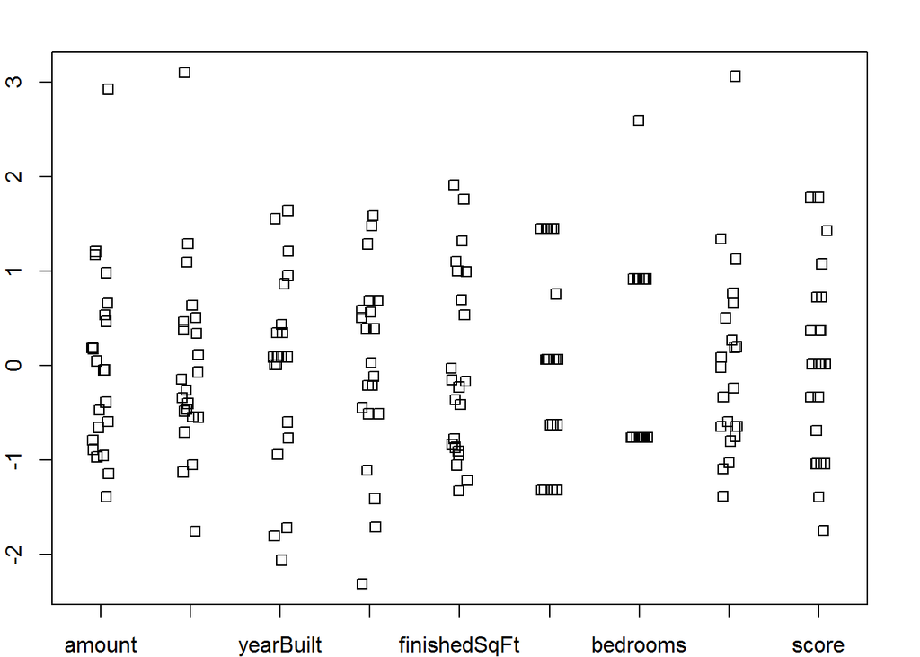

```
##
## Call:
## lm(formula = l.lastSoldPrice ~ ., data = comps)
##
## Residuals:
##       Min        1Q    Median        3Q       Max
## -0.066339 -0.032117 -0.005965  0.030430  0.114948
##
## Coefficients:
##                      Estimate      Std. Error t value Pr(>|t|)
## (Intercept)   21.194627778481  4.546188917006   4.662 0.000549
## amount         0.000001628636  0.000000440879   3.694 0.003069
## taxAssessment  0.000000864223  0.000000775110   1.115 0.286696
## yearBuilt     -0.003279654895  0.001889308038  -1.736 0.108161
## lotSizeSqFt   -0.000026717115  0.000020550129  -1.300 0.217986
## finishedSqFt  -0.000308372921  0.000140771097  -2.191 0.048955
## bathrooms     -0.111206526535  0.044185029416  -2.517 0.027066
## bedrooms       0.032253703274  0.064547509057   0.500 0.626330
## lastSold      -0.000000001059  0.000000002197  -0.482 0.638493
## score         -0.066744559517  0.017302199412  -3.858 0.002279
##
## Residual standard error: 0.06316 on 12 degrees of freedom
## Multiple R-squared:  0.9437, Adjusted R-squared:  0.9015
## F-statistic: 22.36 on 9 and 12 DF,  p-value: 0.000003616
```

### Logarithm of dependent variable “lastSoldPrice”

After taking the log of **lastSoldPrice** , Adjusted R squared value increases from 0.8371658 to 0.9015195.

### Bivariate Relations

Now we explore the scatterplots of all the numeric variables. In the following matrix scatterplot, we see that the **amount** (Zestimate) and **taxAssessment** as well as the usual **finishedSqFt**, **bathrooms** and **bedrooms** are strong predictors of **l.lastSoldPrice**.

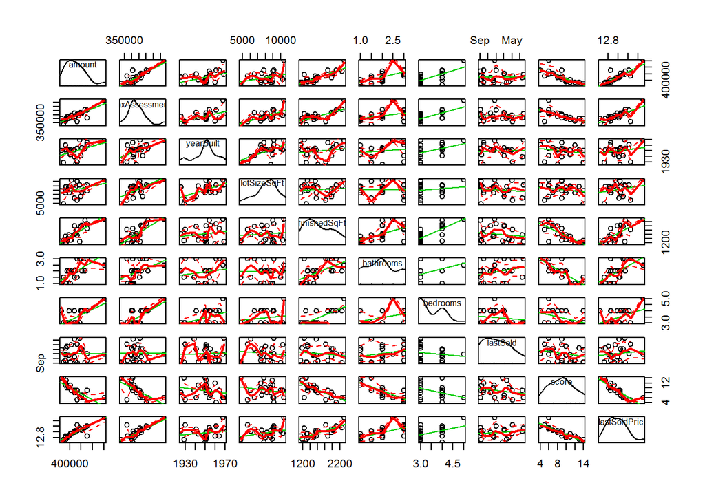

## Model Building

Now we use stepwise regression to explore various models. Here is our first model.

```
##      (Intercept)           amount    taxAssessment        yearBuilt
## 18.7604735851353  0.0000016167492  0.0000009456316 -0.0028545819586
##      lotSizeSqFt     finishedSqFt        bathrooms            score
## -0.0000262814012 -0.0002502040576 -0.0991903219659 -0.0599700344704
```

The model generate negative coefficients for attributes finished sqr foot, no. of bathrooms and lot size which according to the scatter plot(and intuitively) should be positively correlated to the last sold price.

### Model Assumptions Checking

Now we check for non-constant variance, normality of errors, and influential data.

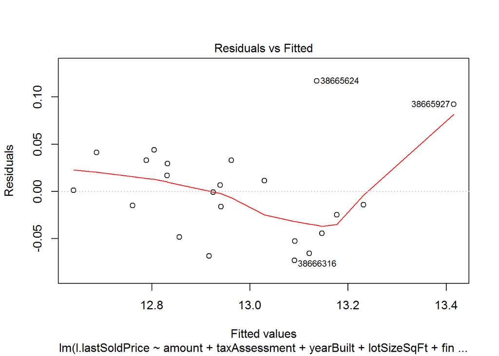

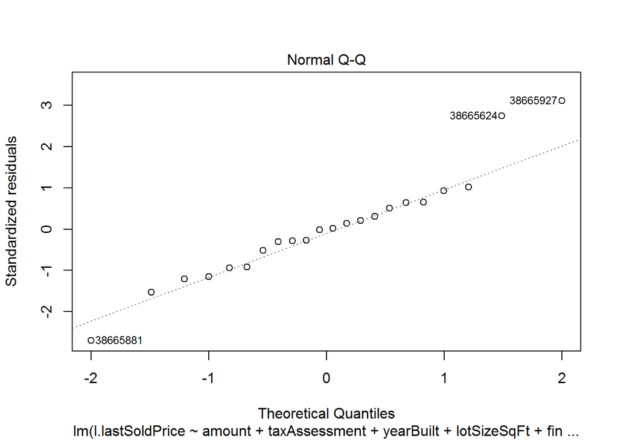

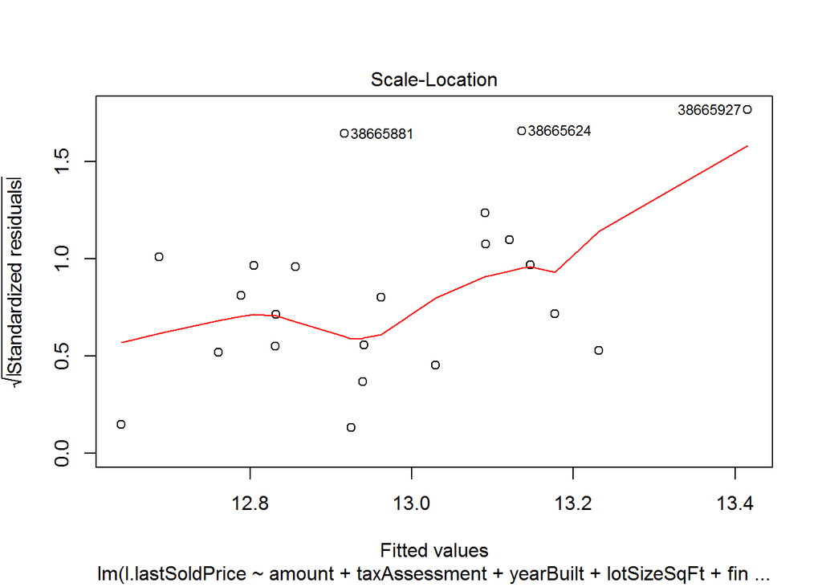

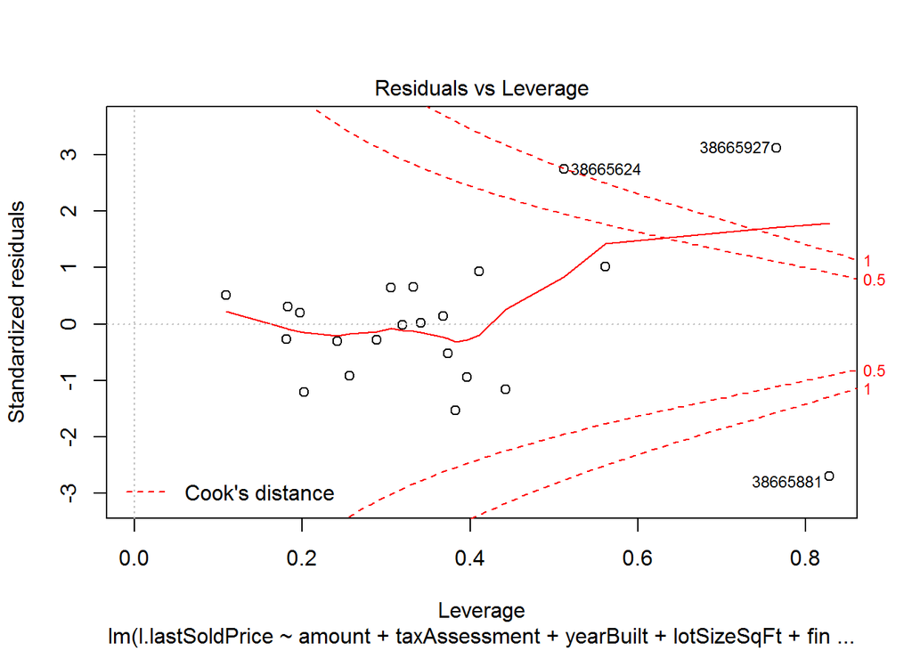

[output not shown]

### Model with out removing leveraged/influencing points – for comparison

```
## Start:  AIC=-92.1
## l.lastSoldPrice ~ amount + taxAssessment + finishedSqFt + bathrooms +
##     bathrooms + lotSizeSqFt
##
##                 Df Sum of Sq     RSS     AIC
## - finishedSqFt   1  0.001186 0.19505 -93.962
## - bathrooms      1  0.004530 0.19840 -93.588
## - lotSizeSqFt    1  0.006056 0.19992 -93.419
## - taxAssessment  1  0.012484 0.20635 -92.723
## <none>                       0.19387 -92.096
## - amount         1  0.050491 0.24436 -89.004
##
## Step:  AIC=-93.96
## l.lastSoldPrice ~ amount + taxAssessment + bathrooms + lotSizeSqFt
##
##                 Df Sum of Sq     RSS     AIC
## - bathrooms      1  0.004457 0.19951 -95.464
## - lotSizeSqFt    1  0.004926 0.19998 -95.413
## - taxAssessment  1  0.011547 0.20660 -94.696
## <none>                       0.19505 -93.962
## - amount         1  0.052777 0.24783 -90.693
##
## Step:  AIC=-95.46
## l.lastSoldPrice ~ amount + taxAssessment + lotSizeSqFt
##
##                 Df Sum of Sq     RSS     AIC
## - lotSizeSqFt    1  0.006960 0.20647 -96.710
## - taxAssessment  1  0.009387 0.20890 -96.453
## <none>                       0.19951 -95.464
## - amount         1  0.112169 0.31168 -87.650
##
## Step:  AIC=-96.71
## l.lastSoldPrice ~ amount + taxAssessment
##
##                 Df Sum of Sq     RSS     AIC
## - taxAssessment  1  0.003138 0.20961 -98.378
## <none>                       0.20647 -96.710
## - amount         1  0.162917 0.36939 -85.913
##
## Step:  AIC=-98.38
## l.lastSoldPrice ~ amount
##
##          Df Sum of Sq     RSS     AIC
## <none>                0.20961 -98.378
## - amount  1   0.64094 0.85055 -69.564
```

```
##    (Intercept)         amount
## 12.08667765728  0.00000198795
```

|  | amount | low | high |
| --- | --- | --- | --- |
| Confidence | 591661.2 | 538102.1 | 650551.2 |
| Prediction | 591661.2 | 468368.2 | 747409.8 |

### —————————————————————————————————————-

### —————————————————————————————————————-

Here is our final model.

```
## Start:  AIC=-118.02
## l.lastSoldPrice ~ amount + taxAssessment + finishedSqFt + bathrooms +
##     bathrooms + lotSizeSqFt
##
##                 Df Sum of Sq      RSS      AIC
## - finishedSqFt   1  0.000378 0.020649 -119.666
## - bathrooms      1  0.000530 0.020802 -119.526
## - lotSizeSqFt    1  0.001435 0.021706 -118.717
## - taxAssessment  1  0.001870 0.022141 -118.340
## <none>                       0.020271 -118.017
## - amount         1  0.097093 0.117364  -86.651
##
## Step:  AIC=-119.67
## l.lastSoldPrice ~ amount + taxAssessment + bathrooms + lotSizeSqFt
##
##                 Df Sum of Sq      RSS      AIC
## - bathrooms      1  0.001113 0.021762 -120.669
## <none>                       0.020649 -119.666
## - lotSizeSqFt    1  0.005092 0.025741 -117.478
## - taxAssessment  1  0.005750 0.026399 -116.999
## - amount         1  0.098804 0.119453  -88.316
##
## Step:  AIC=-120.67
## l.lastSoldPrice ~ amount + taxAssessment + lotSizeSqFt
##
##                 Df Sum of Sq      RSS      AIC
## <none>                       0.021762 -120.669
## - lotSizeSqFt    1  0.004209 0.025971 -119.309
## - taxAssessment  1  0.004946 0.026708 -118.778
## - amount         1  0.113590 0.135352  -87.942
```

```
##      (Intercept)           amount    taxAssessment      lotSizeSqFt
## 12.0152657194524  0.0000028485842 -0.0000009647529  0.0000148708231
```

Let’s recheck the model assumptions.

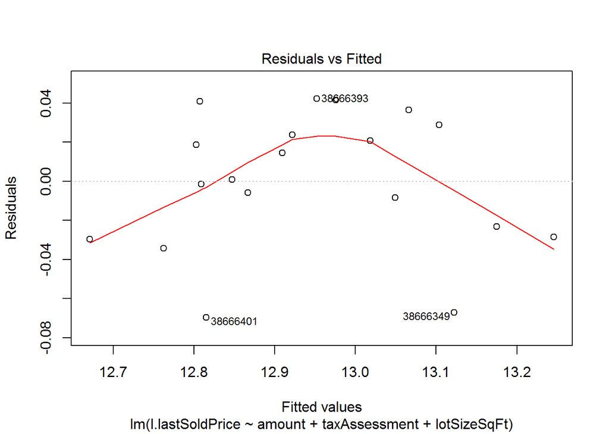

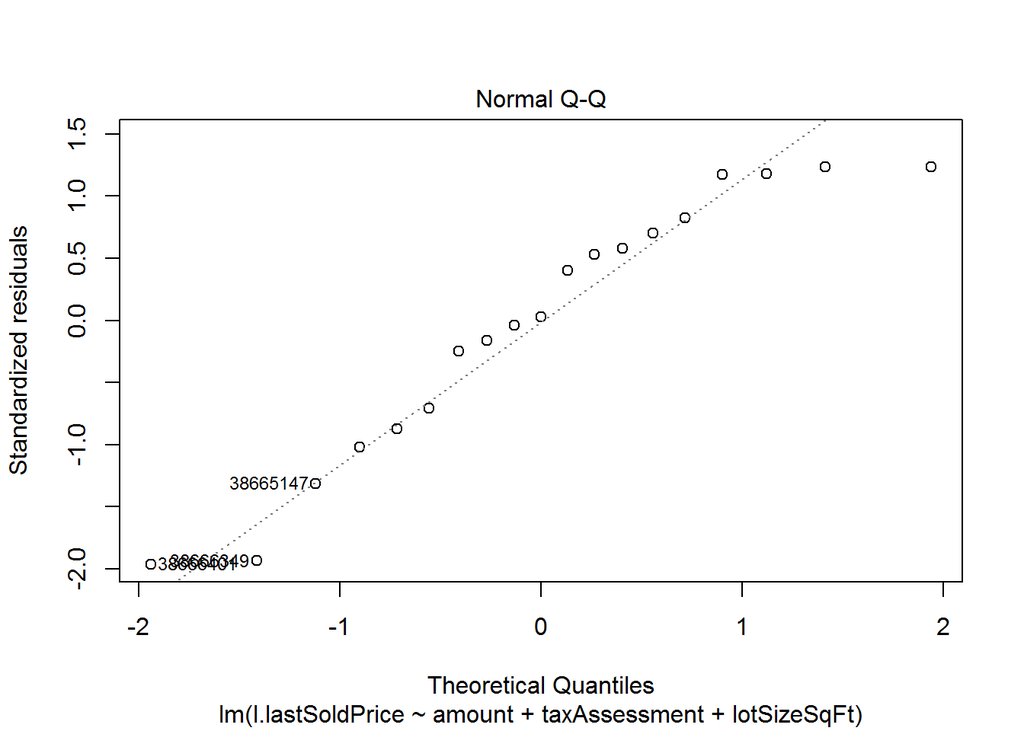

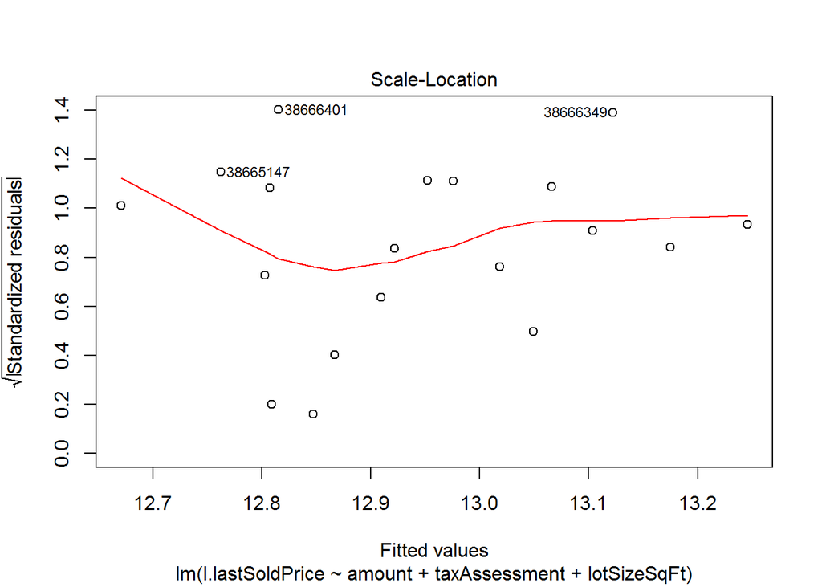

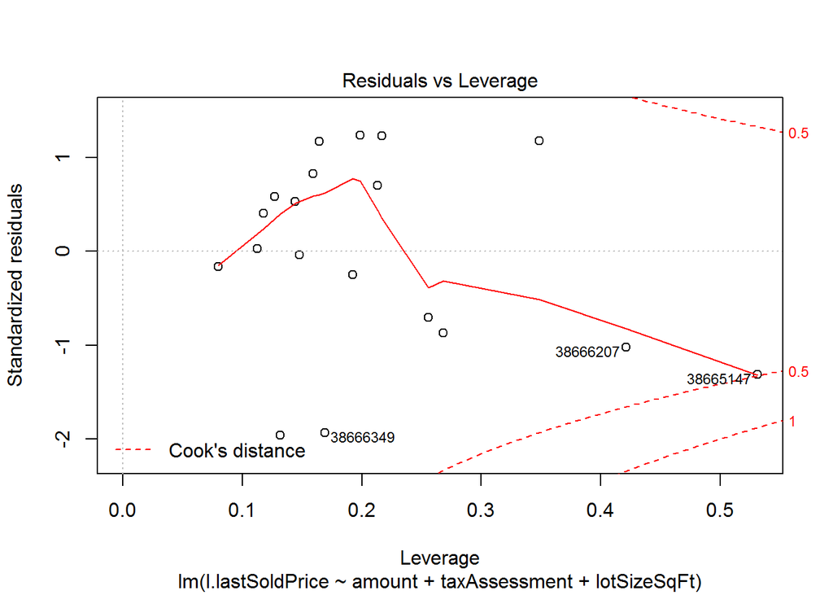

The plots look better. Here is the summary of our final model.

```
##
## Call:
## lm(formula = l.lastSoldPrice ~ amount + taxAssessment + lotSizeSqFt,
##     data = comps_lev)
##
## Residuals:
##       Min        1Q    Median        3Q       Max
## -0.069726 -0.025834  0.000923  0.026235  0.042198
##
## Coefficients:
##                    Estimate    Std. Error t value    Pr(>|t|)
## (Intercept)   12.0152657195  0.0918016508 130.883     < 2e-16
## amount         0.0000028486  0.0000003219   8.848 0.000000244
## taxAssessment -0.0000009648  0.0000005225  -1.846      0.0847
## lotSizeSqFt    0.0000148708  0.0000087303   1.703      0.1091
##
## Residual standard error: 0.03809 on 15 degrees of freedom
## Multiple R-squared:  0.9521, Adjusted R-squared:  0.9425
## F-statistic: 99.38 on 3 and 15 DF,  p-value: 0.000000000402
```

## Prediction Intervals

We now use our final model to predict the selling price of our property. Recall our property’s data is the first row of our original dataset.

|  | amount | low | high | taxAssessment | yearBuilt | finishedSqFt | lotSizeSqFt | bathrooms | bedrooms | lastSoldPrice | lastSold | score |
| --- | --- | --- | --- | --- | --- | --- | --- | --- | --- | --- | --- | --- |
| 38669488 | 605655 | 575372 | 635938 | 527628 | 1963 | 2088 | 13939 | 3 | 4 | 619000 | 2012-08-03 | NA |

Now we need to use this row of data for the prediction intervals, and to compare them with Zestimate, low, and high from Zillow.

|  | amount | low | high |
| --- | --- | --- | --- |
| Zestimate | 605655 | 575372.0 | 635938.0 |
| Confidence | 686100 | 613336.5 | 767495.9 |
| Prediction | 686100 | 597410.9 | 787955.5 |

## Conclusion

The model shows positive correlation to amount and lot size and negative correlation to tax assesment value (Essex county has on of the highest property tax rates in the US and property tax is an important consideration here) which appears to be intuitively correct.

There appears to be disagreement between the confidence interval for average sales price and the Zestimate low-high values. It is interesting to note that zillow estimated price and high/low values are very much in agreement with the model prior to removal of influential(high leverage) points.

There is a difinite agreement between price set by the seller of this property and price estimated by our model. The seller is asking **679000 USD** which is very slightly lower than our predicted value.

note: I very recently purchased a house in Livingston and have found that, in most cases, the zillow estimate is much lower than the price the house actually sells for.